# lab

## Игорь Рухович. 22МАГИАД

### Topic: Christmas

### **Imports:**

```python
%matplotlib inline
from matplotlib import pyplot as plt
import warnings
import pandas as pd
from scipy import stats
import statsmodels.api as sm
from itertools import product
from tqdm import tqdm
from dateutil.relativedelta import relativedelta

warnings.filterwarnings('ignore')
plt.rcParams['figure.figsize'] = 12, 10
```

```python
data_folder = "../data/"
data_fname = "data.csv"

my_name = "Рухович Игорь Владимирович"
my_topic = "Christmas"
year_period = 365
week_period = 7
forecast_period = 14
```

### **Data lookup**

```python
df = pd.read_csv(data_folder + data_fname)
df
```

|  | ФИО | Title | 2021-02-22 | 2021-02-23 | 2021-02-24 | 2021-02-25 | 2021-02-26 | 2021-02-27 | 2021-02-28 | 2021-03-01 | ... | 2023-03-05 | 2023-03-06 | 2023-03-07 | 2023-03-08 | 2023-03-09 | 2023-03-10 | 2023-03-11 | 2023-03-12 | 2023-03-13 | 2023-03-14 |
| --- | --- | --- | --- | --- | --- | --- | --- | --- | --- | --- | --- | --- | --- | --- | --- | --- | --- | --- | --- | --- | --- |
| 0 | Тронин Дмитрий Валерьевич | Тригонометрические функции | 945 | 983 | 1178 | 1236 | 1008 | 790 | 1113 | 1296 | ... | 846 | 1030 | 783 | 740 | 937 | 774 | 691 | 872 | 1027 | 1128 |
| 1 | Воробьев Дмитрий Максимович | Логарифм | 714 | 704 | 886 | 830 | 786 | 712 | 825 | 865 | ... | 613 | 734 | 541 | 546 | 776 | 659 | 505 | 631 | 776 | 653 |
| 2 | Пьянзин Артём Алексеевич | Экспонента | 382 | 392 | 499 | 532 | 446 | 421 | 442 | 525 | ... | 339 | 479 | 423 | 367 | 449 | 441 | 429 | 366 | 539 | 594 |
| 3 | Абрамова Полина Александровна | Гиперболические функции | 457 | 471 | 573 | 616 | 522 | 426 | 571 | 593 | ... | 395 | 462 | 376 | 334 | 388 | 413 | 336 | 393 | 480 | 511 |
| 4 | NaN | Обратные тригонометрические функции | 361 | 442 | 492 | 436 | 350 | 371 | 413 | 502 | ... | 361 | 412 | 307 | 323 | 441 | 413 | 263 | 411 | 478 | 491 |
| ... | ... | ... | ... | ... | ... | ... | ... | ... | ... | ... | ... | ... | ... | ... | ... | ... | ... | ... | ... | ... | ... |
| 71 | NaN | March 11 | 285 | 329 | 346 | 434 | 338 | 311 | 421 | 733 | ... | 567 | 845 | 821 | 1155 | 1608 | 6468 | 19300 | 4388 | 1453 | 646 |
| 72 | NaN | March 10 | 258 | 268 | 300 | 352 | 304 | 266 | 312 | 646 | ... | 768 | 1154 | 1404 | 2074 | 8438 | 30034 | 4483 | 1009 | 943 | 530 |
| 73 | Поляков Валерий Игоревич | March 15 | 258 | 314 | 320 | 339 | 301 | 247 | 362 | 643 | ... | 513 | 699 | 645 | 819 | 961 | 1026 | 925 | 1564 | 2451 | 9290 |
| 74 | NaN | October 1 | 92 | 92 | 73 | 50 | 98 | 89 | 85 | 87 | ... | 66 | 81 | 67 | 100 | 74 | 98 | 108 | 99 | 111 | 110 |
| 75 | NaN | September 21 | 92 | 77 | 102 | 74 | 83 | 112 | 70 | 97 | ... | 57 | 94 | 96 | 105 | 103 | 114 | 108 | 92 | 126 | 117 |

76 rows × 753 columns

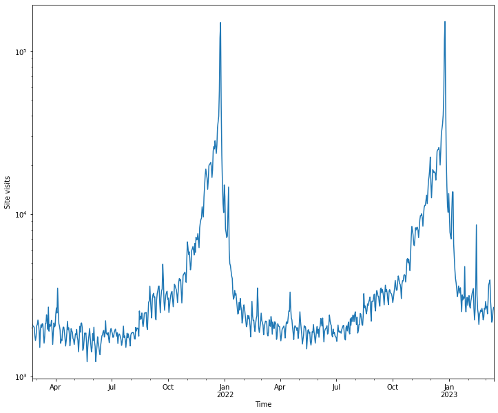

```python
christmas_df = pd.Series(df.loc[df["ФИО"] == my_name, "2021-02-22":].values.squeeze(),
                         index = pd.to_datetime(df.columns[2:]),
                         name = my_topic)
christmas_df.plot()
plt.yscale("log")
plt.ylabel("Site visits")
plt.xlabel("Time")
```

Видим явную сезонность: тема "рождество" интересует пользователей Википедии во время самого праздника и менее интересна летом.

### **Decomposition**

Попробуем провести декомпозицию:

```
Dickey-Fuller criterion: p=0.000000
```

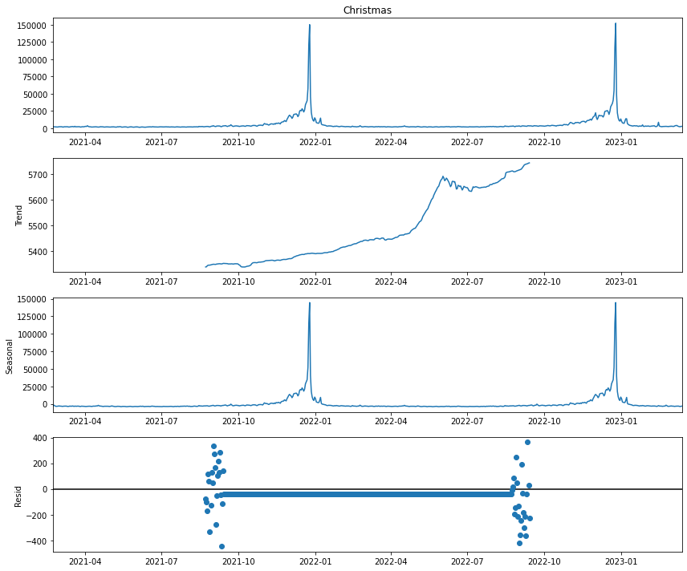

```python
sm.tsa.seasonal_decompose(christmas_df, period=year_period).plot()
print(f"Dickey-Fuller criterion: p={sm.tsa.stattools.adfuller(christmas_df)[1]:.6f}")
```

Критерий Dickey-Fuller отвергает гипотезу о нестационарности выборки, но глазами мы видим выраженную сезонность. Проведём дифференцирование:

```
Dickey-Fuller criterion: p=0.051731
```

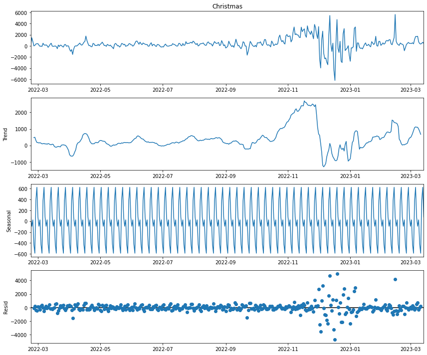

```python
df_shifted = christmas_df - christmas_df.shift(year_period)
sm.tsa.seasonal_decompose(df_shifted[year_period:], period=week_period).plot()
print(f"Dickey-Fuller criterion: p={sm.tsa.stattools.adfuller(df_shifted[year_period:])[1]:.6f}")
```

Для годового периода теперь недостаточно данных: необходимо 2 полных цикла, зато теперь видим недельную сезонность. Тест теперь едва ли отвергает гипотезу о нестационарности выборки, проведём повторное дифференцирование с периодом 7 дней:

```
Dickey-Fuller criterion: p=0.000010
```

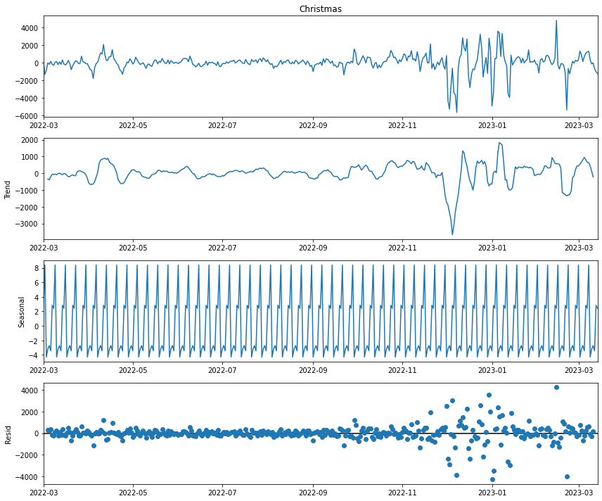

```python
df_shifted_twice = df_shifted - df_shifted.shift(week_period)
sm.tsa.seasonal_decompose(df_shifted_twice[year_period + week_period:], period=week_period).plot()
print(f"Dickey-Fuller criterion: p={sm.tsa.stattools.adfuller(df_shifted_twice[year_period +\
                                                                               week_period:])[1]:.6f}")
```

Стало намного лучше: не видим выраженной сезонности, но остаётся тренд - проведём в модели дополнительно одно дифференцирование по соседним значениям.

**Дополнительно замечу, что поскольку в задании требуется предсказать поведение за 14 дней, где само рождество не будет встречаться, то мы можем (ввиду недостатка данных) не обращать внимания на такую сезонность, а работать только с недельной.** 7х52=364, практически 365. То есть годовой сдвиг включает в себя множитель 7, а значит, если мы тренируем модель с недельным периодом, необходимо будет дифференцировать по сезонности дважды (за "год" и за "неделю").

Посмотрим также на автокорреляцию остатков:

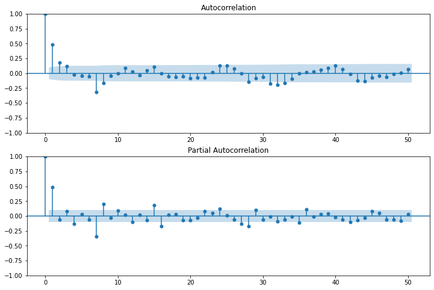

```python
df_diff = df_shifted_twice[year_period + week_period:]

plt.figure(figsize=(12, 8))
ax = plt.subplot(211)
sm.graphics.tsa.plot_acf(df_diff.values.squeeze(),
                         lags=50, ax=ax)
ax = plt.subplot(212)
sm.graphics.tsa.plot_pacf(df_diff.values.squeeze(),
                          lags=50, ax=ax);
```

### **SARIMA**

Попробуем перебрать разные значения гиперпараметров SARIMA:

```python
ps = range(0, 4)
d=1
qs = range(0, 1)
Ps = range(0, 3)
D=2
Qs = range(0, 3)

parameters = product(ps, qs, Ps, Qs)
parameters_list = list(parameters)
len(parameters_list)
```

```
36
```

```python
%%time
results = []
best_aic = float("inf")

warnings.filterwarnings('ignore')

for param in tqdm(parameters_list):
    #try except is needed because some parameter combinations are not valid
    try:
        model=sm.tsa.statespace.SARIMAX(christmas_df, order=(param[0], d, param[1]),
                                        seasonal_order=(param[2], D,
                                                        param[3], week_period)).fit(disp=-1)
    except ValueError:
        print('wrong parameters:', param)
        continue
    aic = model.aic
    # save best model, it's AIC and params
    if aic < best_aic:
        best_model = model
        best_aic = aic
        best_param = param
    results.append([param, model.aic])

warnings.filterwarnings('default')
```

```
CPU times: user 4min 30s, sys: 2min 9s, total: 6min 39s
Wall time: 1min 9s
```

Верхушка таблицы параметров лучших моделей (по AIC, правдоподобие минус число параметров):

```python
result_table = pd.DataFrame(results)
result_table.columns = ['parameters', 'aic']
print(result_table.sort_values(by = 'aic', ascending=True).head())
```

```
      parameters           aic
20  (2, 0, 0, 2)  15056.789496
23  (2, 0, 1, 2)  15057.936661
29  (3, 0, 0, 2)  15057.940854
32  (3, 0, 1, 2)  15059.246643
26  (2, 0, 2, 2)  15143.999774
```

В целом можно сказать, что число параметров по порядку сильно отличается от лосса, поэтому правильнее в такой метрике было бы брать эти значения с коэффициентами, но не будем спорить с учеными :)

```python
print(best_model.summary())
```

```
                                       SARIMAX Results
==============================================================================================
Dep. Variable:                              Christmas   No. Observations:                  751
Model:             SARIMAX(2, 1, 0)x(0, 2, [1, 2], 7)   Log Likelihood               -7523.395
Date:                                Mon, 27 Mar 2023   AIC                          15056.789
Time:                                        02:40:55   BIC                          15079.796
Sample:                                    02-22-2021   HQIC                         15065.662
                                         - 03-14-2023
Covariance Type:                                  opg
==============================================================================
                 coef    std err          z      P>|z|      [0.025      0.975]
------------------------------------------------------------------------------
ar.L1          0.2068      0.014     14.805      0.000       0.179       0.234
ar.L2         -0.3679      0.008    -48.237      0.000      -0.383      -0.353
ma.S.L7       -1.9930      0.015   -131.269      0.000      -2.023      -1.963
ma.S.L14       0.9931      0.016     62.781      0.000       0.962       1.024
sigma2       3.93e+07   7.83e-10   5.02e+16      0.000    3.93e+07    3.93e+07
===================================================================================
Ljung-Box (L1) (Q):                   0.12   Jarque-Bera (JB):            451042.59
Prob(Q):                              0.73   Prob(JB):                         0.00
Heteroskedasticity (H):             680.04   Skew:                            -5.08
Prob(H) (two-sided):                  0.00   Kurtosis:                       123.85
===================================================================================

Warnings:
[1] Covariance matrix calculated using the outer product of gradients (complex-step).
[2] Covariance matrix is singular or near-singular, with condition number 1.17e+31. Standard errors may be unstable.
```

Посмотрим на участок, не включающий рождество:

```
Dickey-Fuller criterion: p=0.000000
```

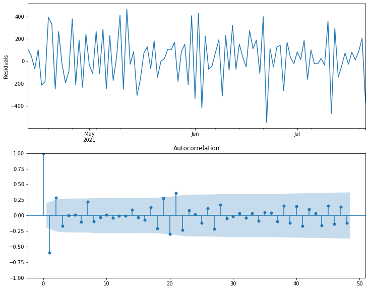

```python
plt.subplot(211)
best_model.resid[50:150].plot()
plt.ylabel(u'Residuals')

ax = plt.subplot(212)
sm.graphics.tsa.plot_acf(best_model.resid[50:150].values.squeeze(), lags=48, ax=ax)

print("Dickey-Fuller criterion: p=%f" % sm.tsa.stattools.adfuller(best_model.resid[15:])[1])
```

**Напоминаю, что из-за недостатка данных по годам, не получается обучить SARIMA на годовых сезонных интервалах. По хорошему, в этой задаче следует взять больше данных (например, за 10 лет) и более мощную модель, позволяющую находить несколько сезонностей**

### **Forecast & Outcome**

Посмотрим на качество аппроксимации:

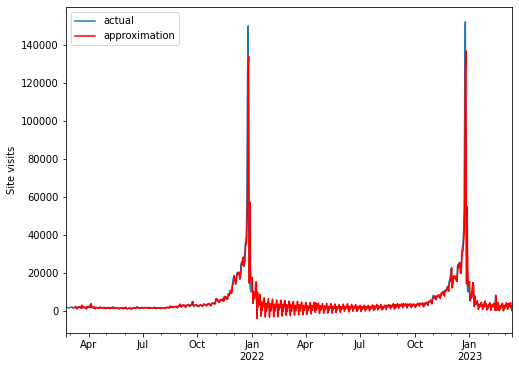

```python
plt.figure(figsize=(8, 6))
approx_vals = best_model.fittedvalues
christmas_df.plot(label='actual')
approx_vals[15:].plot(color='r', label='approximation')
plt.ylabel("Site visits")
plt.legend()
```

Видим, что модель довольно четко описала данные, хотя и имеется значительный разброс с января по май 2022. Попробуем произвести предсказание на 14 следующих дней:

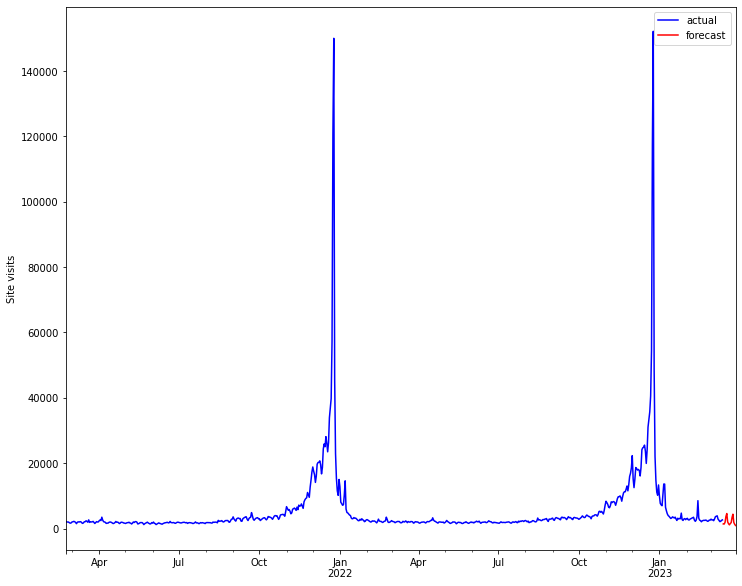

```python
christmas_df.plot(color='b', label='actual')
best_model.predict(christmas_df.shape[0], christmas_df.shape[0] + forecast_period)\
          .plot(color='r', label='forecast')
plt.ylabel("Site visits")
plt.legend()
```

Предсказания в сыром виде:

```python
best_model.predict(christmas_df.shape[0], christmas_df.shape[0] + forecast_period)
```

```
2023-03-15    1430.748978
2023-03-16    1400.046627
2023-03-17    1912.997049
2023-03-18    3694.400955
2023-03-19    4611.827742
2023-03-20    2052.321312
2023-03-21    1480.804943
2023-03-22    1150.353571
2023-03-23    1562.180912
2023-03-24    1830.194831
2023-03-25    3420.846543
2023-03-26    4407.531510
2023-03-27    1900.250334
2023-03-28    1323.093192
2023-03-29     955.410781
Freq: D, Name: predicted_mean, dtype: float64
```

Предсказания получились немного разбросанными. Полагаю, что это произошло из-за недостаточного объема исходных данных и слабой модели: в данных явно присутствует 2 сезонности, но для годовой мы имеем немногим больше 2 циклов, а после первого дифференцирования фактически теряем половину датасета.

Для более точных прогнозов хочется использовать модель с возможностью нахождения нескольких сезонностей.